# Warm-up exercise

A solution

Kálmán Abari

2021-09-12

# Data structures

## Problems

Consider the following set of attributes about the American Film Institute’s top-five movies ever from their 2007 list.

1. What code would you use to create a vector named `Movie` with the values `Citizen Kane`, `The Godfather`, `Casablanca`, `Raging Bull`, and `Singing in the Rain`? (Hints: `object <- c()`, Working with character in R)

```r
# Solution ----
Movie <- c("Citizen Kane", "The Godfather", "Casablanca", "Raging Bull",
    "Singing in the Rain")
Movie
```

```
#> [1] "Citizen Kane"        "The Godfather"
#> [3] "Casablanca"          "Raging Bull"
#> [5] "Singing in the Rain"
```

2. What code would you use to create a vector — giving the year that the movies in Problem 1 were made — named `Year` with the values 1941, 1972, 1942, 1980, and 1952?

```r
# Solution ----
Year <- c(1941, 1972, 1942, 1980, 1952)
Year
```

```
#> [1] 1941 1972 1942 1980 1952
```

3. What code would you use to create a vector — giving the run times in minutes of the movies in Problem 1 — named `RunTime` with the values 119, 177, 102, 129, and 103?

```r
# Solution ----
RunTime <- c(119, 177, 102, 129, 103)
RunTime
```

```
#> [1] 119 177 102 129 103
```

4. What code would you use to find the run times of the movies in hours and save them in a vector called `RunTimeHours`? (Hints: Numeric tranformation)

```r
# Solution ----
RunTimeHours <- RunTime/60
RunTimeHours
```

```
#> [1] 1.983333 2.950000 1.700000 2.150000 1.716667
```

5. What code would you use to create a data frame named `MovieInfo` containing the vectors created in Problem 1, Problem 2, and Problem 3? (Hints: `data.frame()`)

```r
# Solution ----
MovieInfo <- data.frame(Movie, Year, RunTime)
MovieInfo
```

```
#>                 Movie Year RunTime
#> 1        Citizen Kane 1941     119
#> 2       The Godfather 1972     177
#> 3          Casablanca 1942     102
#> 4         Raging Bull 1980     129
#> 5 Singing in the Rain 1952     103
```

```r
str(MovieInfo)
```

```
#> 'data.frame':    5 obs. of  3 variables:
#>  $ Movie  : chr  "Citizen Kane" "The Godfather" "Casablanca" "Raging Bull" ...
#>  $ Year   : num  1941 1972 1942 1980 1952
#>  $ RunTime: num  119 177 102 129 103
```

# Manipulation

## Problems

Suppose we have the following data frame named `colleges` (download here):

| College | Employees | TopSalary | MedianSalary |
| --- | --- | --- | --- |
| William and Mary | 2104 | 425000 | 56496 |
| Christopher Newport | 922 | 381486 | 47895 |
| George Mason | 4043 | 536714 | 63029 |
| James Madison | 2833 | 428400 | 53080 |
| Longwood | 746 | 328268 | 52000 |
| Norfolk State | 919 | 295000 | 49605 |
| Old Dominion | 2369 | 448272 | 54416 |
| Radford | 1273 | 312080 | 51000 |
| Mary Washington | 721 | 449865 | 53045 |
| Virginia | 7431 | 561099 | 60048 |
| Virginia Commonwealth | 5825 | 503154 | 55000 |
| Virginia Military Institute | 550 | 364269 | 44999 |
| Virginia Tech | 7303 | 500000 | 51656 |
| Virginia State | 761 | 356524 | 55925 |

1. What code would you use to select the first, third, tenth, and twelfth entries in the `TopSalary` vector from the `Colleges` data frame? (Hints: Indexing with `[]` operator)

```r
# Solution ----
library(rio)
colleges <- import(file = "data/colleges.xlsx")
str(colleges)
```

```
#> 'data.frame':    14 obs. of  4 variables:
#>  $ College     : chr  "William and Mary" "Christopher Newport" "George Mason" "James Madison" ...
#>  $ Employees   : num  2104 922 4043 2833 746 ...
#>  $ TopSalary   : num  425000 381486 536714 428400 328268 ...
#>  $ MedianSalary: num  56496 47895 63029 53080 52000 ...
```

```r
colleges$College <- factor(colleges$College)  # convert to factor
colleges$TopSalary[c(1, 3, 10, 12)]
```

```
#> [1] 425000 536714 561099 364269
```

2. What code would you use to select the elements of the `MedianSalary` vector where the `TopSalary` is greater than $400,000? (Hints: `d$MedianSalary[d$TopSalary>400000]`)

```r
# Solution ----
colleges$MedianSalary[colleges$TopSalary > 4e+05]
```

```
#> [1] 56496 63029 53080 54416 53045 60048 55000 51656
```

3. What code would you use to select the rows of the data frame for colleges with less than or equal to 1000 employees? (Hints: `d[condition, ]`)

```r
# Solution ----
colleges[colleges$Employees <= 1000, ]
```

```
#>                        College Employees TopSalary
#> 2          Christopher Newport       922    381486
#> 5                     Longwood       746    328268
#> 6                Norfolk State       919    295000
#> 9              Mary Washington       721    449865
#> 12 Virginia Military Institute       550    364269
#> 14              Virginia State       761    356524
#>    MedianSalary
#> 2         47895
#> 5         52000
#> 6         49605
#> 9         53045
#> 12        44999
#> 14        55925
```

4. What code would you use to select a sample of 5 colleges from this data frame (there are 14 rows)? (Hints: `d[sample(x = 1:14, size = 5, replace = F),]`)

```r
# Solution ----
colleges[sample(x = 1:14, size = 5, replace = F), ]
```

```
#>                        College Employees TopSalary
#> 13               Virginia Tech      7303    500000
#> 14              Virginia State       761    356524
#> 1             William and Mary      2104    425000
#> 12 Virginia Military Institute       550    364269
#> 9              Mary Washington       721    449865
#>    MedianSalary
#> 13        51656
#> 14        55925
#> 1         56496
#> 12        44999
#> 9         53045
```

Suppose we have the following data frame named Countries (download here):

| Nation | Region | Population | PctIncrease | GDPcapita |
| --- | --- | --- | --- | --- |
| China | Asia | 1409517397 | 0.4 | 8582 |
| India | Asia | 1339180127 | 1.1 | 1852 |
| United States | North America | 324459463 | 0.7 | 57467 |
| Indonesia | Asia | 263991379 | 1.1 | 3895 |
| Brazil | South America | 209288278 | 0.8 | 10309 |
| Pakistan | Asia | 197015955 | 2.0 | 1629 |
| Nigeria | Africa | 190886311 | 2.6 | 2640 |
| Bangladesh | Asia | 164669751 | 1.1 | 1524 |
| Russia | Europe | 143989754 | 0.0 | 10248 |
| Mexico | North America | 129163276 | 1.3 | 8562 |

5. What could would you use to select the rows of the data frame that have GDP per capita less than 10000 and are not in the Asia region?

```r
# Solution ----
library(rio)
Countries <- import(file = "data/countries.xlsx")
Countries$Region <- factor(Countries$Region)
Countries[Countries$GDPcapita < 10000 & !(Countries$Region %in%
    "Asia"), ]
```

```
#>     Nation        Region Population PctIncrease GDPcapita
#> 7  Nigeria        Africa  190886311         2.6      2640
#> 10  Mexico North America  129163276         1.3      8562
```

6. What code would you use to select a sample of three nations from this data frame (There are 10 rows)?

```r
# Solution ----
Countries[sample(x = 1:10, size = 3, replace = F), ]
```

```
#>     Nation        Region Population PctIncrease GDPcapita
#> 10  Mexico North America  129163276         1.3      8562
#> 7  Nigeria        Africa  190886311         2.6      2640
#> 2    India          Asia 1339180127         1.1      1852
```

7. What code would you use to select which nations saw a population percent increase greater that 1.5%?

```r
# Solution ----
Countries[Countries$PctIncrease > 1.5, ]
```

```
#>     Nation Region Population PctIncrease GDPcapita
#> 6 Pakistan   Asia  197015955         2.0      1629
#> 7  Nigeria Africa  190886311         2.6      2640
```

Suppose we have the following data frame named Olympics (download here):

| Year | Type | Host | Competitors | Events | Nations | Leader |
| --- | --- | --- | --- | --- | --- | --- |
| 1992 | Summer | Spain | 9356 | 257 | 169 | Unified Team |
| 1992 | Winter | France | 1801 | 57 | 64 | Germany |
| 1994 | Winter | Norway | 1737 | 61 | 67 | Russia |
| 1996 | Summer | United States | 10318 | 271 | 197 | United States |
| 1998 | Winter | Japan | 2176 | 68 | 72 | Germany |
| 2000 | Summer | Australia | 10651 | 300 | 199 | United States |
| 2002 | Winter | United States | 2399 | 78 | 78 | Norway |
| 2004 | Summer | Greece | 10625 | 301 | 201 | United States |
| 2006 | Winter | Italy | 2508 | 84 | 80 | Germany |
| 2008 | Summer | China | 10942 | 302 | 204 | China |
| 2010 | Winter | Canada | 2566 | 86 | 82 | Canada |
| 2012 | Summer | United Kingdom | 10768 | 302 | 204 | United States |
| 2014 | Winter | Russia | 2873 | 98 | 88 | Russia |
| 2016 | Summer | Brazil | 11238 | 306 | 207 | United States |
| 2018 | Winter | South Korea | 2922 | 102 | 92 | Norway |

8. What code would you use to select the rows of the data frame where the host nation was also the medal leader?

```r
# Solution ----
library(rio)
Olympics <- import(file = "data/olympics.xlsx")
Olympics$Type <- factor(Olympics$Type)
Olympics$Host <- factor(Olympics$Host)
Olympics$Leader <- factor(Olympics$Leader)
Olympics[as.character(Olympics$Host) == as.character(Olympics$Leader),
    ]
```

```
#>    Year   Type          Host Competitors Events Nations
#> 4  1996 Summer United States       10318    271     197
#> 10 2008 Summer         China       10942    302     204
#> 11 2010 Winter        Canada        2566     86      82
#> 13 2014 Winter        Russia        2873     98      88
#>           Leader
#> 4  United States
#> 10         China
#> 11        Canada
#> 13        Russia
```

9. What code would you use to select the rows of the data frame where the number of competitors per event is greater than 35?

```r
# Solution ----
Olympics[Olympics$Competitors/Olympics$Events > 35, ]
```

```
#>    Year   Type           Host Competitors Events Nations
#> 1  1992 Summer          Spain        9356    257     169
#> 4  1996 Summer  United States       10318    271     197
#> 6  2000 Summer      Australia       10651    300     199
#> 8  2004 Summer         Greece       10625    301     201
#> 10 2008 Summer          China       10942    302     204
#> 12 2012 Summer United Kingdom       10768    302     204
#> 14 2016 Summer         Brazil       11238    306     207
#>           Leader
#> 1   Unified Team
#> 4  United States
#> 6  United States
#> 8  United States
#> 10         China
#> 12 United States
#> 14 United States
```

10. What code would you use to select the rows of the data frame where the number of competing nations in the Winter Olympics is at least 80?

```r
# Solution ----
Olympics[Olympics$Nations >= 80 & Olympics$Type == "Winter",
    ]
```

```
#>    Year   Type        Host Competitors Events Nations
#> 9  2006 Winter       Italy        2508     84      80
#> 11 2010 Winter      Canada        2566     86      82
#> 13 2014 Winter      Russia        2873     98      88
#> 15 2018 Winter South Korea        2922    102      92
#>     Leader
#> 9  Germany
#> 11  Canada
#> 13  Russia
#> 15  Norway
```

# Packages

## Problems

1. Install the **Ecdat** package. (Hints: `install.packages()`)

```r
# Solution ----
install.packages("Ecdat")
```

2. Say that we previously installed the **Ecdat** library into R and wanted to call the library to access datasets from it. What code would we use to call the library? (Hints: `library()`)

```r
# Solution ----
library("Ecdat")
```

3. Say that we then wanted to call the dataset `Diamond` from the **Ecdat** library. What code would we use to load this dataset into R? (Hints: `data()`)

```r
# Solution ----
data("Diamond")
str(Diamond)
```

```
#> 'data.frame':    308 obs. of  5 variables:
#>  $ carat        : num  0.3 0.3 0.3 0.3 0.31 0.31 0.31 0.31 0.31 0.31 ...
#>  $ colour       : Factor w/ 6 levels "D","E","F","G",..: 1 2 4 4 1 2 3 4 5 6 ...
#>  $ clarity      : Factor w/ 5 levels "IF","VS1","VS2",..: 3 2 4 2 2 2 2 5 3 2 ...
#>  $ certification: Factor w/ 3 levels "GIA","HRD","IGI": 1 1 1 1 1 1 1 1 1 1 ...
#>  $ price        : int  1302 1510 1510 1260 1641 1555 1427 1427 1126 1126 ...
```

# Frequency and numerical exploratory analyses

## Problems

Load the `leuk` dataset from the *MASS* library. This dataset is the survival times (`time`), white blood cell count (`wbc`), and the presence of a morphologic characteristic of white blood cells (`ag`).

1. Generate the frequency table for the presence of the morphologic characteristic.

```r
# Solution ----
data("leuk", package = "MASS")
str(leuk)
```

```
#> 'data.frame':    33 obs. of  3 variables:
#>  $ wbc : int  2300 750 4300 2600 6000 10500 10000 17000 5400 7000 ...
#>  $ ag  : Factor w/ 2 levels "absent","present": 2 2 2 2 2 2 2 2 2 2 ...
#>  $ time: int  65 156 100 134 16 108 121 4 39 143 ...
```

```r
table(leuk$ag)
```

```
#>
#>  absent present
#>      16      17
```

```r
DescTools::Desc(leuk$ag, plotit = F, )
```

```
#> ----------------------------------------------------------
#> leuk$ag (factor - dichotomous)
#>
#>   length      n    NAs unique
#>       33     33      0      2
#>          100.0%   0.0%
#>
#>          freq   perc  lci.95  uci.95'
#> absent     16  48.5%   32.5%   64.8%
#> present    17  51.5%   35.2%   67.5%
#>
#> ' 95%-CI (Wilson)
```

```r
# Solution ----
median(leuk$time)
```

```
#> [1] 22
```

3. Find the range, IQR, variance, and standard deviation for white blood cell count.

```r
# Solution ----
diff(range(leuk$wbc))  # range
```

```
#> [1] 99250
```

```r
IQR(leuk$wbc)
```

```
#> [1] 26700
```

```r
var(leuk$wbc)
```

```
#> [1] 1189517888
```

```r
sd(leuk$wbc)
```

```
#> [1] 34489.39
```

4. Find the correlation between white blood cell count and survival time.

```r
# Solution ----
cor(leuk$wbc, leuk$time)
```

```
#> [1] -0.3294525
```

Load the `survey` dataset from the *MASS* library. This dataset contains the survey responses of a class of college students.

5. Create the contingency table of whether or not the student smoked (`Smoke`) and the student’s exercise regimen (`Exer`). (Hints: `table()`, `DescTools::Desc()`)

```r
# Solution ----
data("survey", package = "MASS")
str(survey)
```

```
#> 'data.frame':    237 obs. of  12 variables:
#>  $ Sex   : Factor w/ 2 levels "Female","Male": 1 2 2 2 2 1 2 1 2 2 ...
#>  $ Wr.Hnd: num  18.5 19.5 18 18.8 20 18 17.7 17 20 18.5 ...
#>  $ NW.Hnd: num  18 20.5 13.3 18.9 20 17.7 17.7 17.3 19.5 18.5 ...
#>  $ W.Hnd : Factor w/ 2 levels "Left","Right": 2 1 2 2 2 2 2 2 2 2 ...
#>  $ Fold  : Factor w/ 3 levels "L on R","Neither",..: 3 3 1 3 2 1 1 3 3 3 ...
#>  $ Pulse : int  92 104 87 NA 35 64 83 74 72 90 ...
#>  $ Clap  : Factor w/ 3 levels "Left","Neither",..: 1 1 2 2 3 3 3 3 3 3 ...
#>  $ Exer  : Factor w/ 3 levels "Freq","None",..: 3 2 2 2 3 3 1 1 3 3 ...
#>  $ Smoke : Factor w/ 4 levels "Heavy","Never",..: 2 4 3 2 2 2 2 2 2 2 ...
#>  $ Height: num  173 178 NA 160 165 ...
#>  $ M.I   : Factor w/ 2 levels "Imperial","Metric": 2 1 NA 2 2 1 1 2 2 2 ...
#>  $ Age   : num  18.2 17.6 16.9 20.3 23.7 ...
```

```r
# recode factor Smoke
levels(survey$Smoke)
```

```
#> [1] "Heavy" "Never" "Occas" "Regul"
```

```r
survey$Smoke <- car::recode(survey$Smoke, "c(\"Heavy\",\"Occas\",\"Regul\")=\"Yes\";\"Never\"=\"No\"")
table(survey$Smoke, survey$Exer)
```

```
#>
#>       Freq None Some
#>   No    87   18   84
#>   Yes   28    5   14
```

```r
DescTools::Desc(Smoke ~ Exer, data = survey, plotit = F, )
```

```
#> ----------------------------------------------------------
#> Smoke ~ Exer (survey)
#>
#> Summary:
#> n: 236, rows: 2, columns: 3
#>
#> Pearson's Chi-squared test:
#>   X-squared = 3.412, df = 2, p-value = 0.1816
#> Log likelihood ratio (G-test) test of independence:
#>   G = 3.5037, X-squared df = 2, p-value = 0.1735
#> Mantel-Haenszel Chi-squared:
#>   X-squared = 3.3215, df = 1, p-value = 0.06838
#>
#> Warning message:
#>   Exp. counts < 5: Chi-squared approx. may be incorrect!!
#>
#>
#> Phi-Coefficient        0.120
#> Contingency Coeff.     0.119
#> Cramer's V             0.120
#>
#>
#>         Exer    Freq   None   Some    Sum
#> Smoke
#>
#> No      freq      87     18     84    189
#>         perc   36.9%   7.6%  35.6%  80.1%
#>         p.row  46.0%   9.5%  44.4%      .
#>         p.col  75.7%  78.3%  85.7%      .
#>
#> Yes     freq      28      5     14     47
#>         perc   11.9%   2.1%   5.9%  19.9%
#>         p.row  59.6%  10.6%  29.8%      .
#>         p.col  24.3%  21.7%  14.3%      .
#>
#> Sum     freq     115     23     98    236
#>         perc   48.7%   9.7%  41.5% 100.0%
#>         p.row      .      .      .      .
#>         p.col      .      .      .      .
#>
```

6. Find the mean and median of the student’s heart rate (`Pulse`). (Hints: `summary()`, `DescTools::Desc()`, `psych::describe()`)

```r
# Solution ----
mean(survey$Pulse, na.rm = T)
```

```
#> [1] 74.15104
```

```r
median(survey$Pulse, na.rm = T)
```

```
#> [1] 72.5
```

```r
summary(survey$Pulse)
```

```
#>    Min. 1st Qu.  Median    Mean 3rd Qu.    Max.    NA's
#>   35.00   66.00   72.50   74.15   80.00  104.00      45
```

```r
psych::describe(survey$Pulse)
```

```
#>    vars   n  mean    sd median trimmed   mad min max range
#> X1    1 192 74.15 11.69   72.5   74.02 11.12  35 104    69
#>     skew kurtosis   se
#> X1 -0.02     0.33 0.84
```

```r
DescTools::Desc(survey$Pulse, plotit = F)
```

```
#> ----------------------------------------------------------
#> survey$Pulse (integer)
#>
#>   length      n    NAs  unique     0s   mean  meanCI'
#>      237    192     45      43      0  74.15   72.49
#>           81.0%  19.0%           0.0%          75.81
#>
#>      .05    .10    .25  median    .75    .90     .95
#>    59.55  60.00  66.00   72.50  80.00  90.00   92.00
#>
#>    range     sd  vcoef     mad    IQR   skew    kurt
#>    69.00  11.69   0.16   11.12  14.00  -0.02    0.33
#>
#> lowest : 35, 40, 48 (2), 50 (2), 54
#> highest: 96 (3), 97, 98, 100 (2), 104 (2)
#>
#> heap(?): remarkable frequency (9.4%) for the mode(s) (= 80)
#>
#> ' 95%-CI (classic)
```

7. Find the range, IQR, variance, and standard deviation for student age (`Age`).

```r
# Solution ----
diff(range(survey$Age))  # range
```

```
#> [1] 56.25
```

```r
IQR(survey$Age)
```

```
#> [1] 2.5
```

```r
var(survey$Age)
```

```
#> [1] 41.91701
```

```r
sd(survey$Age)
```

```
#> [1] 6.474335
```

8. Find the correlation between the span of the student’s writing hand (`Wr.Hnd`) and nonwriting hand (`NW.Hnd`). (Hints: `cor()`, `DescTools::Desc()`)

```r
# Solution ----
cor(survey$Wr.Hnd, survey$NW.Hnd, use = "complete.obs")
```

```
#> [1] 0.9483103
```

```r
DescTools::Desc(Wr.Hnd ~ NW.Hnd, data = survey, plotit = F)
```

```
#> ----------------------------------------------------------
#> Wr.Hnd ~ NW.Hnd (survey)
#>
#> Summary:
#> n pairs: 237, valid: 236 (99.6%), missings: 1 (0.4%)
#>
#>
#> Pearson corr. : 0.948
#> Spearman corr.: 0.952
#> Kendall corr. : 0.842
```

Load the `Housing` dataset from the *Ecdat* library. This dataset looks at the variables that affect the sales price of houses.

9. Create the contingency table of whether or not the house has a recreation room (`recroom`) and whether or not the house had a full basement (`fullbase`).

```r
# Solution ----
data("Housing", package = "Ecdat")
str(Housing)
```

```
#> 'data.frame':    546 obs. of  12 variables:
#>  $ price   : num  42000 38500 49500 60500 61000 66000 66000 69000 83800 88500 ...
#>  $ lotsize : num  5850 4000 3060 6650 6360 4160 3880 4160 4800 5500 ...
#>  $ bedrooms: num  3 2 3 3 2 3 3 3 3 3 ...
#>  $ bathrms : num  1 1 1 1 1 1 2 1 1 2 ...
#>  $ stories : num  2 1 1 2 1 1 2 3 1 4 ...
#>  $ driveway: Factor w/ 2 levels "no","yes": 2 2 2 2 2 2 2 2 2 2 ...
#>  $ recroom : Factor w/ 2 levels "no","yes": 1 1 1 2 1 2 1 1 2 2 ...
#>  $ fullbase: Factor w/ 2 levels "no","yes": 2 1 1 1 1 2 2 1 2 1 ...
#>  $ gashw   : Factor w/ 2 levels "no","yes": 1 1 1 1 1 1 1 1 1 1 ...
#>  $ airco   : Factor w/ 2 levels "no","yes": 1 1 1 1 1 2 1 1 1 2 ...
#>  $ garagepl: num  1 0 0 0 0 0 2 0 0 1 ...
#>  $ prefarea: Factor w/ 2 levels "no","yes": 1 1 1 1 1 1 1 1 1 1 ...
```

```r
table(Housing$recroom, Housing$fullbase)
```

```
#>
#>        no yes
#>   no  329 120
#>   yes  26  71
```

```r
DescTools::Desc(recroom ~ fullbase, data = Housing, plotit = F,
    )
```

```
#> ----------------------------------------------------------
#> recroom ~ fullbase (Housing)
#>
#> Summary:
#> n: 546, rows: 2, columns: 2
#>
#> Pearson's Chi-squared test (cont. adj):
#>   X-squared = 73.705, df = 1, p-value < 2.2e-16
#> Fisher's exact test p-value < 2.2e-16
#> McNemar's chi-squared = 59.24, df = 1, p-value = 1.396e-14
#>
#>                     estimate lwr.ci upr.ci'
#>
#> odds ratio             7.487  4.561 12.289
#> rel. risk (col1)       2.734  1.958  3.816
#> rel. risk (col2)       0.365  0.300  0.444
#>
#>
#> Phi-Coefficient        0.372
#> Contingency Coeff.     0.349
#> Cramer's V             0.372
#>
#>
#>           fullbase     no    yes    Sum
#> recroom
#>
#> no        freq        329    120    449
#>           perc      60.3%  22.0%  82.2%
#>           p.row     73.3%  26.7%      .
#>           p.col     92.7%  62.8%      .
#>
#> yes       freq         26     71     97
#>           perc       4.8%  13.0%  17.8%
#>           p.row     26.8%  73.2%      .
#>           p.col      7.3%  37.2%      .
#>
#> Sum       freq        355    191    546
#>           perc      65.0%  35.0% 100.0%
#>           p.row         .      .      .
#>           p.col         .      .      .
#>
#>
#> ----------
#> ' 95% conf. level
```

10. Find the mean and median of the house’s lot size (`lotsize`).

```r
# Solution ----
mean(Housing$lotsize)
```

```
#> [1] 5150.266
```

```r
median(Housing$lotsize)
```

```
#> [1] 4600
```

11. Find the range, IQR, variance, and standard deviation for the sales price (`price`).

```r
# Solution ----
DescTools::Desc(Housing$price, plotit = F)
```

```
#> ----------------------------------------------------------
#> Housing$price (numeric)
#>
#>       length          n        NAs     unique         0s'
#>          546        546          0        219          0
#>                  100.0%       0.0%                  0.0%
#>
#>          .05        .10        .25     median        .75
#>    35'000.00  40'500.00  49'125.00  62'000.00  82'000.00
#>
#>        range         sd      vcoef        mad        IQR
#>   165'000.00  26'702.67       0.39  22'239.00  32'875.00
#>
#>         mean      meanCI
#>    68'121.60   65'876.83
#>                70'366.37
#>
#>          .90         .95
#>   105'000.00  120'000.00
#>
#>         skew        kurt
#>         1.20        1.91
#>
#> lowest : 25'000.0 (3), 25'245.0, 26'000.0, 26'500.0, 27'000.0 (2)
#> highest: 155'000.0, 163'000.0, 174'500.0, 175'000.0 (2), 190'000.0
#>
#> ' 95%-CI (classic)
```

12. Find the correlation between the sales price of the house (`price`) and the number of bedrooms (`bedrooms`).

```r
# Solution ----
cor(Housing$price, Housing$bedrooms)
```

```
#> [1] 0.3664474
```

```r
DescTools::Desc(price ~ bedrooms, data = Housing, plotit = F)
```

```
#> ----------------------------------------------------------
#> price ~ bedrooms (Housing)
#>
#> Summary:
#> n pairs: 546, valid: 546 (100.0%), missings: 0 (0.0%)
#>
#>
#> Pearson corr. : 0.366
#> Spearman corr.: 0.390
#> Kendall corr. : 0.307
```

# Graphical exploratory analyses

Load the `Star` dataset from the *Ecdat* library. This dataset looks at the affect on class sizes on student learning.

1. Generate the scatterplot of the student’s math score `tmathssk` and reading score `treadssk`. (Hints: `plot()`, `ggplot() + geom_point()`)

```r
# Solution ----
data("Star", package = "Ecdat")
str(Star)
```

```
#> 'data.frame':    5748 obs. of  8 variables:
#>  $ tmathssk: int  473 536 463 559 489 454 423 500 439 528 ...
#>  $ treadssk: int  447 450 439 448 447 431 395 451 478 455 ...
#>  $ classk  : Factor w/ 3 levels "regular","small.class",..: 2 2 3 1 2 1 3 1 2 2 ...
#>  $ totexpk : int  7 21 0 16 5 8 17 3 11 10 ...
#>  $ sex     : Factor w/ 2 levels "girl","boy": 1 1 2 2 2 2 1 1 1 1 ...
#>  $ freelunk: Factor w/ 2 levels "no","yes": 1 1 2 1 2 2 2 1 1 1 ...
#>  $ race    : Factor w/ 3 levels "white","black",..: 1 2 2 1 1 1 2 1 2 1 ...
#>  $ schidkn : int  63 20 19 69 79 5 16 56 11 66 ...
#>  - attr(*, "na.action")= 'omit' Named int [1:5850] 1 4 6 7 8 9 10 15 16 17 ...
#>   ..- attr(*, "names")= chr [1:5850] "1" "4" "6" "7" ...
```

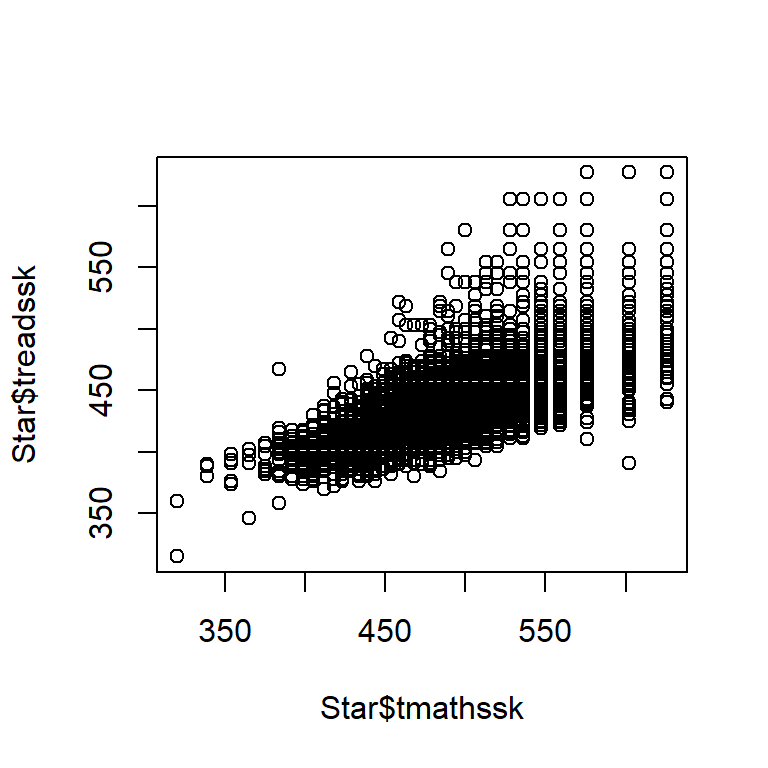

```r
# Solution ----
plot(Star$tmathssk, Star$treadssk)
```

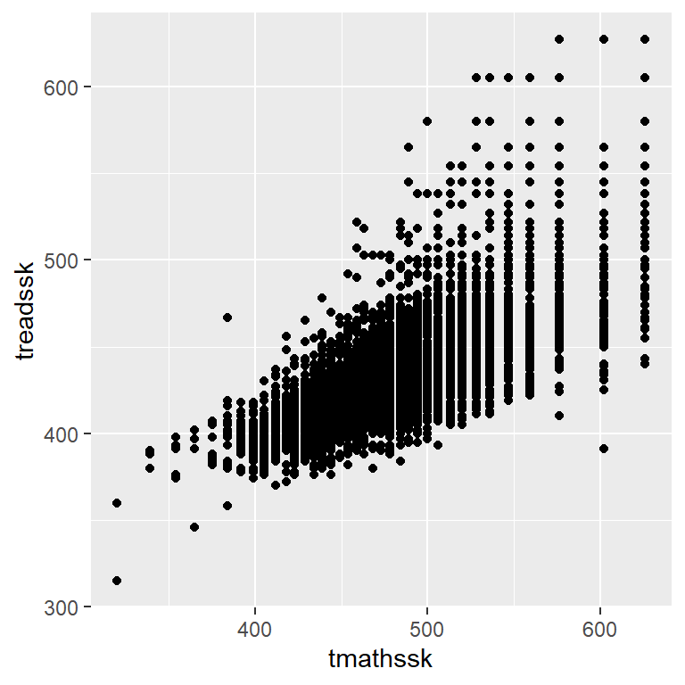

```r
# Solution ----
library(ggplot2)
ggplot(data = Star, mapping = aes(x = tmathssk, y = treadssk)) +
    geom_point()
```

2. Generate the histogram of the years of teaching experience `totexpk`. (Hints: `hist()`, `ggplot() + geom_histogram()`)

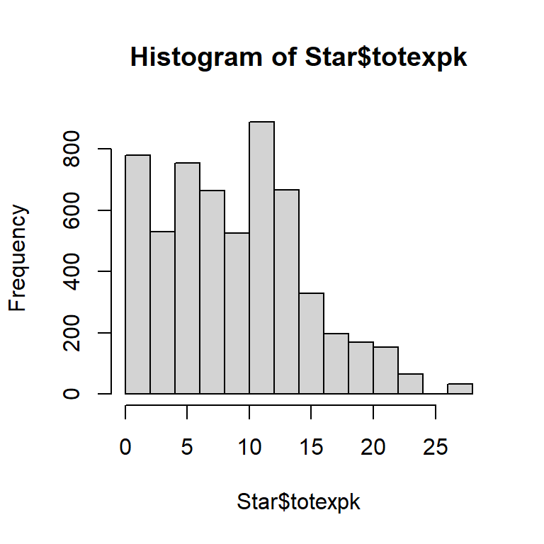

```r
# Solution ----
hist(Star$totexpk)
```

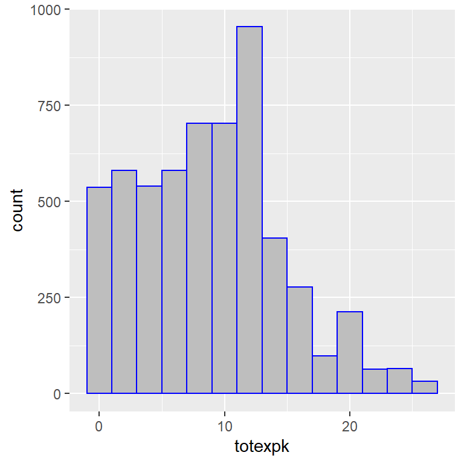

```r
# Solution ----
library(ggplot2)
ggplot(data = Star, mapping = aes(x = totexpk)) + geom_histogram(binwidth = 2,
    fill = "grey", col = "blue")
```

3. Create a new variable in the `Star` dataset called `totalscore` that is the sum of the student’s math score `tmathssk` and reading score `treadssk`. (Hints: tranformation)

```r
# Solution ----
Star$totalscore <- Star$tmathssk + Star$treadssk
```

4. Generate a boxplot of the student’s total score `totalscore` split out by the class size type `classk`. (Hints: `boxplot()`, `ggplot() + geom_boxplot()`)

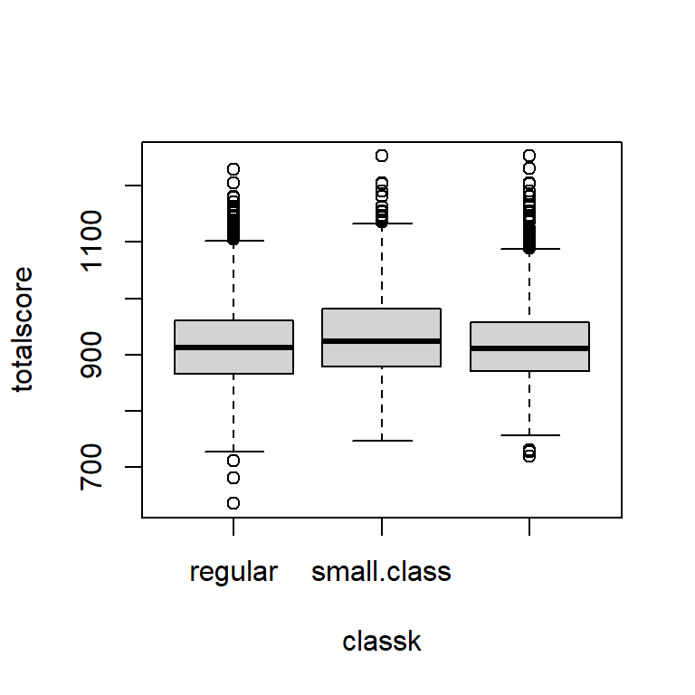

```r
# Solution ----
boxplot(totalscore ~ classk, data = Star)
```

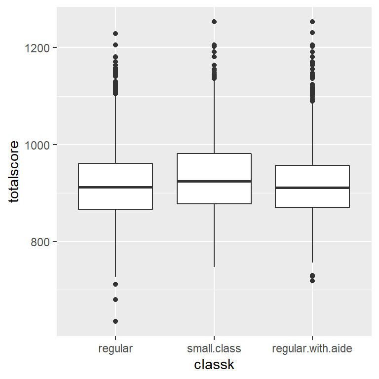

```r
# Solution ----
library(ggplot2)
ggplot(data = Star, mapping = aes(x = classk, y = totalscore)) +
    geom_boxplot()
```

Load the `survey` dataset from the *MASS* library. This dataset contains the survey responses of a class of college students.

5. Generate the scatterplot of the student’s height `Height` and writing hand span `Wr.Hnd`.

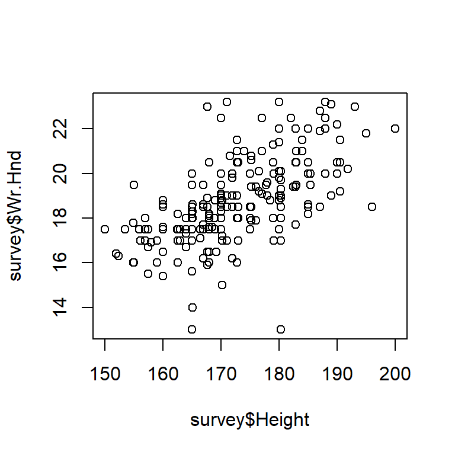

```r
# Solution ----
plot(survey$Height, survey$Wr.Hnd)
```

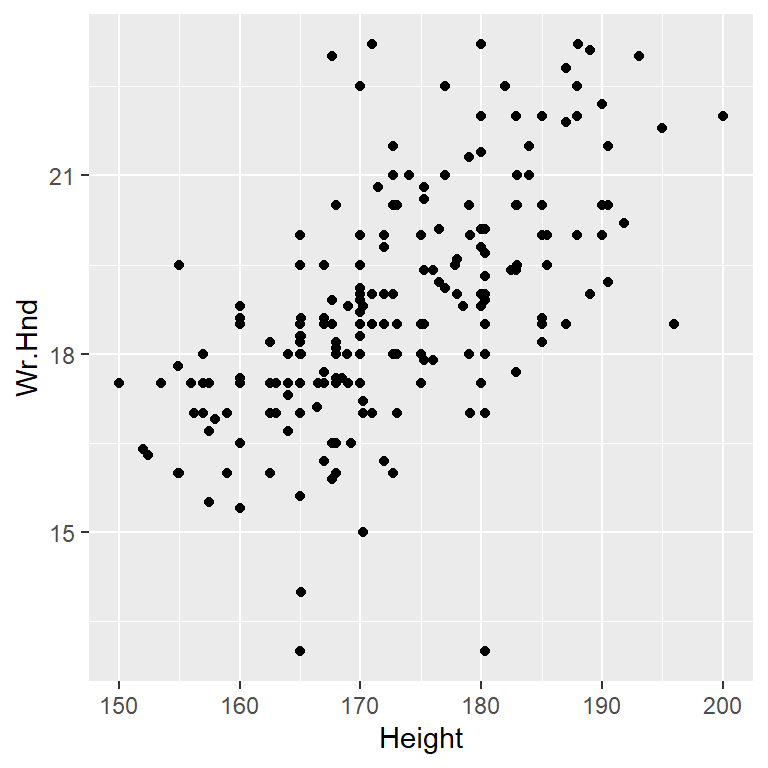

```r
# Solution ----
library(ggplot2)
ggplot(data = survey, mapping = aes(x = Height, y = Wr.Hnd)) +
    geom_point()
```

6. Generate the histogram of student age `Age`.

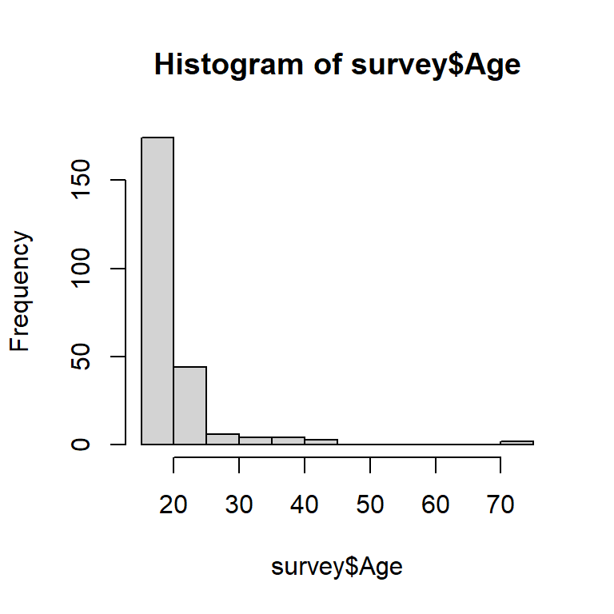

```r
# Solution ----
hist(survey$Age)
```

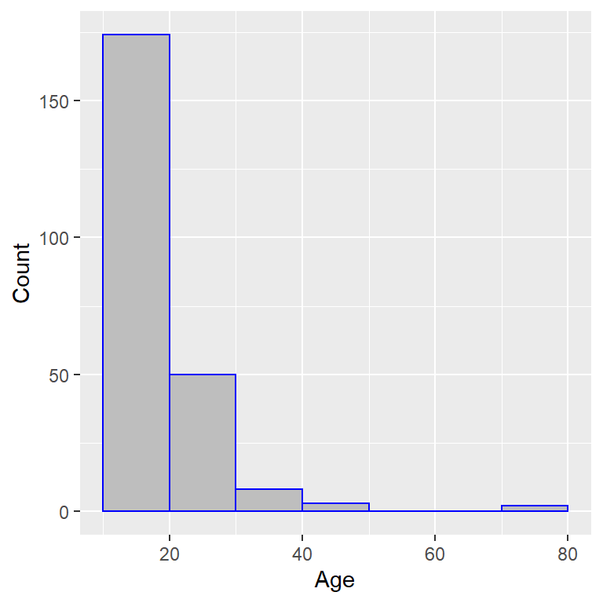

```r
# Solution ----
library(ggplot2)
ggplot(data = survey, mapping = aes(x = Age)) + geom_histogram(binwidth = 10,
    fill = "grey", col = "blue", boundary = 10) + labs(x = "Age",
    y = "Count")
```

7. Generate a boxplot of the student’s heart rate `Pulse` split out by the student’s exercise regimen `Exer`.

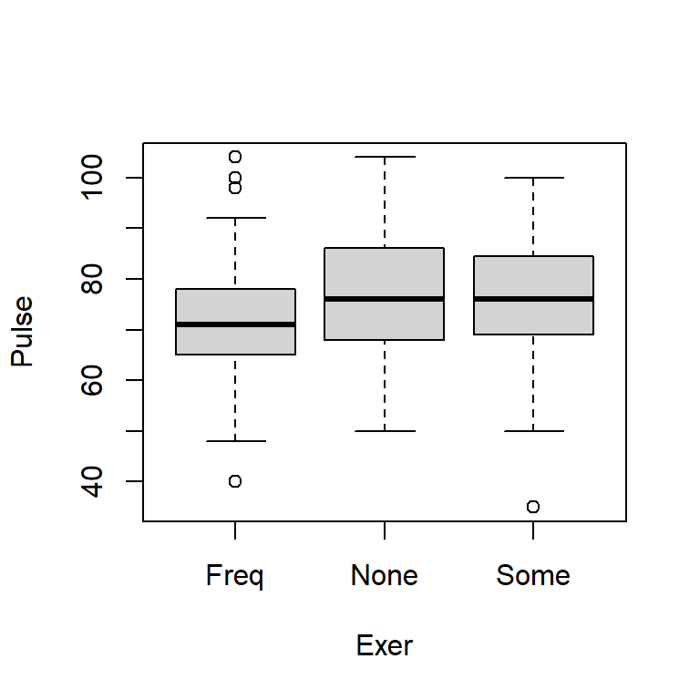

```r
# Solution ----
boxplot(Pulse ~ Exer, data = survey)
```

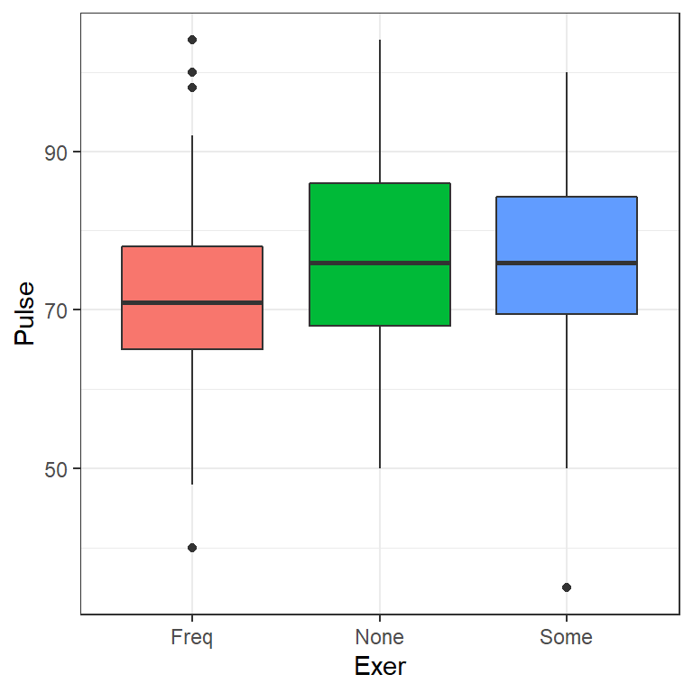

```r
# Solution ----
library(ggplot2)
ggplot(data = survey, mapping = aes(x = Exer, y = Pulse, fill = Exer)) +
    geom_boxplot() + theme_bw() + theme(legend.position = "none")
```

# Reference

Loftus, S C. 2021. *Basic Statistics with R: Reaching Decisions with Data*. Elsevier Science. https://books.google.hu/books?id=vTASEAAAQBAJ.